# deep-learning-final-notebook

**IMPORTING ALL THE REQUIRED PACKAGES AND LIBRARIES**

```python
import spacy
import wordcloud
import numpy as np
import pandas as pd
import seaborn as sns
import plotly.express as px
import matplotlib.pyplot as plt

from sklearn.model_selection import train_test_split
from sklearn.model_selection import GridSearchCV
from sklearn.model_selection import train_test_split
from sklearn import metrics
from sklearn.tree import DecisionTreeClassifier
from sklearn.ensemble import RandomForestClassifier
from sklearn.linear_model import LogisticRegression
from sklearn.neighbors import KNeighborsClassifier
from sklearn.preprocessing import LabelEncoder
from keras.models import Model
from keras.layers import LSTM, Activation, Dense, Dropout, Input, Embedding
from keras.preprocessing.text import Tokenizer
from keras.preprocessing import sequence

%matplotlib inline

import warnings
warnings.filterwarnings('ignore')
```

**Read the test & train directory**

```python
TRAIN_DIR = "../input/feedback-prize-2021/train"
TEST_DIR = "../input/feedback-prize-2021/test"
train = os.listdir(TRAIN_DIR)
test = os.listdir(TEST_DIR)

for file in range(len(train)):
    train[file] = TRAIN_DIR + "/" + str(train[file])

for file in range(len(test)):
    test[file] = TEST_DIR + "/" + str(test[file])

train_df = pd.read_csv("../input/feedback-prize-2021/train.csv")
sub_df = pd.read_csv("../input/feedback-prize-2021/sample_submission.csv")
```

**PERFORMING EDA**

**To print out the number of train and test files**

```python
print("No. of train files: ", len(train))
print("No. of test files: ", len(test))
```

```
No. of train files:  15594
No. of test files:  5
```

**shape of the dataset**

```python
print(train_df.shape)
```

```
(144293, 8)
```

**Columns present in the dataset**

```python
train_df.columns
```

```
Index(['id', 'discourse_id', 'discourse_start', 'discourse_end',
       'discourse_text', 'discourse_type', 'discourse_type_num',
       'predictionstring'],
      dtype='object')
```

**Checking missing values**

```python
train_df.isnull().sum()
```

```
id                    0
discourse_id          0
discourse_start       0
discourse_end         0
discourse_text        0
discourse_type        0
discourse_type_num    0
predictionstring      0
dtype: int64
```

**No missing data is found in train dataset**

**Getting descriptive statistics summary**

```python
train_df.describe()
```

|  | discourse_id | discourse_start | discourse_end |
| --- | --- | --- | --- |
| count | 1.442930e+05 | 144293.000000 | 144293.000000 |
| mean | 1.618936e+12 | 959.818855 | 1200.791203 |
| std | 2.491895e+09 | 921.054471 | 1010.457306 |
| min | 1.614351e+12 | 0.000000 | 3.000000 |
| 25% | 1.616884e+12 | 277.000000 | 422.000000 |
| 50% | 1.618862e+12 | 685.000000 | 927.000000 |
| 75% | 1.621222e+12 | 1404.000000 | 1696.000000 |
| max | 1.623614e+12 | 7510.000000 | 7947.000000 |

**Get the information of data Frame**

```python
train_df.info()
```

```
<class 'pandas.core.frame.DataFrame'>
RangeIndex: 144293 entries, 0 to 144292
Data columns (total 8 columns):
 #   Column              Non-Null Count   Dtype
---  ------              --------------   -----
 0   id                  144293 non-null  object
 1   discourse_id        144293 non-null  float64
 2   discourse_start     144293 non-null  float64
 3   discourse_end       144293 non-null  float64
 4   discourse_text      144293 non-null  object
 5   discourse_type      144293 non-null  object
 6   discourse_type_num  144293 non-null  object
 7   predictionstring    144293 non-null  object
dtypes: float64(3), object(5)
memory usage: 8.8+ MB
```

```python
train_df.head()
```

|  | id | discourse_id | discourse_start | discourse_end | discourse_text | discourse_type | discourse_type_num | predictionstring |
| --- | --- | --- | --- | --- | --- | --- | --- | --- |
| 0 | 423A1CA112E2 | 1.622628e+12 | 8.0 | 229.0 | Modern humans today are always on their phone.... | Lead | Lead 1 | 1 2 3 4 5 6 7 8 9 10 11 12 13 14 15 16 17 18 1... |
| 1 | 423A1CA112E2 | 1.622628e+12 | 230.0 | 312.0 | They are some really bad consequences when stu... | Position | Position 1 | 45 46 47 48 49 50 51 52 53 54 55 56 57 58 59 |
| 2 | 423A1CA112E2 | 1.622628e+12 | 313.0 | 401.0 | Some certain areas in the United States ban ph... | Evidence | Evidence 1 | 60 61 62 63 64 65 66 67 68 69 70 71 72 73 74 75 |
| 3 | 423A1CA112E2 | 1.622628e+12 | 402.0 | 758.0 | When people have phones, they know about certa... | Evidence | Evidence 2 | 76 77 78 79 80 81 82 83 84 85 86 87 88 89 90 9... |
| 4 | 423A1CA112E2 | 1.622628e+12 | 759.0 | 886.0 | Driving is one of the way how to get around. P... | Claim | Claim 1 | 139 140 141 142 143 144 145 146 147 148 149 15... |

**PERFORMING DATA VISUALISATION**

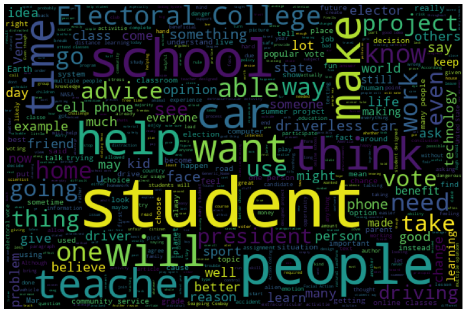

```python
wordcloud = wordcloud.WordCloud(stopwords=wordcloud.STOPWORDS, max_font_size=90, max_words=4500, width=600, height=400, background_color='black').generate(' '.join(txt for txt in train_df["discourse_text"]))
fig, ax = plt.subplots(figsize=(14,10))
ax.imshow(wordcloud, interpolation='bilinear')
ax.set_axis_off()
plt.imshow(wordcloud);
```

```python
train_df["discourse_type"].unique()
```

```
array(['Lead', 'Position', 'Evidence', 'Claim', 'Concluding Statement',
       'Counterclaim', 'Rebuttal'], dtype=object)
```

```python
fig = px.bar(x=np.unique(train_df["discourse_type"]), y=[list(train_df["discourse_type"]).count(i) for i in np.unique(train_df["discourse_type"])], color=np.unique(train_df["discourse_type"]), color_continuous_scale="Mint")
fig.update_xaxes(title="Classes")
fig.update_yaxes(title="Number of Rows")
fig.update_layout(showlegend=True,
                  title={
                      'text':'Discourse Type Distribution',
                      'y':0.95,
                      'x':0.5,
                      'xanchor':'center',
                      'yanchor':'top'}, template="seaborn")
fig.show()
```

[interactive chart not shown]

We can see that the number of Claim stated in the essay is 50K,  
Concluding Statement is about 13K,  
Counterclaim is 5817,  
Lead is 9305,  
Position is about 15K, and  
Rebuttal is 4337

**function to add value labels**

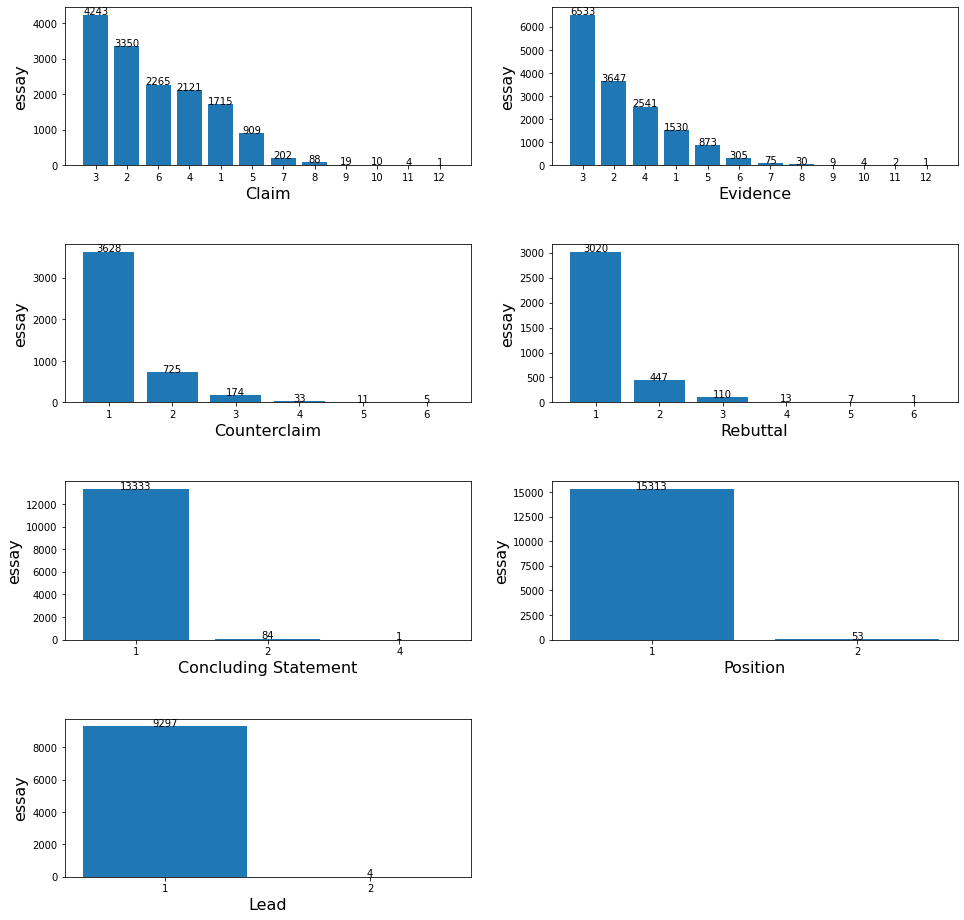

```python
def addlabels(x,y):
    for i in range(len(x)):
        plt.text(i,y[i],y[i], ha = 'center')

temp = train_df[["id","discourse_type"]].value_counts().rename_axis(["id","discourse_type"]).reset_index(name='counts')
discourse_types=temp["discourse_type"].unique()

plt.figure(figsize=(16, 16))
plt.subplots_adjust(hspace=0.5)

for i in range(len(discourse_types)):
    df=temp[temp["discourse_type"]==discourse_types[i]][["counts"]].value_counts().rename_axis(discourse_types[i]).reset_index(name='essay')
    #plt.figure(figsize= (16, 16))
    df[discourse_types[i]]=df[discourse_types[i]].apply(str)
    df= df.sort_values('essay',ascending=False)
    ax = plt.subplot(4, 2, i + 1)
    plt.bar(discourse_types[i], 'essay',data=df)
    addlabels(df[discourse_types[i]], df["essay"])
    plt.xlabel(discourse_types[i],size=16)
    plt.ylabel('essay',size=16)

plt.show()
```

**The distribution of each discourse type in the text.**

**It can be seen from these figures that the number of "Claim" and "Evidence" in the article is relatively large, but the number of "Concluding Statement", "Position" and "Lead" in the article is relatively small.**

**Natural language processing**

It invloves parsing of text and find the semantic meaning of student answer and finally compare it with instructors answer and assign the final scores.Natural language processing techniques were used to extract features from essays in the dataset. . The data was divided into two parts: training data and testing data.

**BASIC NLP AUGMENTATIONS**

```python
from nltk import sent_tokenize
from albumentations.core.transforms_interface import DualTransform, BasicTransform

from termcolor import colored

import tensorflow as tf
from tensorflow import keras
```

```python
class config:
    SEED = 42
    DIRECTORY_PATH = "../input/feedback-prize-2021"
    TRAIN_CSV_PATH = os.path.join(DIRECTORY_PATH, 'train.csv')
```

```python
import random
from tqdm import tqdm
def set_seed(seed=config.SEED):
    random.seed(seed)
    os.environ["PYTHONHASHSEED"] = str(seed)
    np.random.seed(seed)

set_seed()
```

```python
#LOAD THE DATASET
train = pd.read_csv(config.TRAIN_CSV_PATH)
```

```python
train.head()
```

|  | id | discourse_id | discourse_start | discourse_end | discourse_text | discourse_type | discourse_type_num | predictionstring |
| --- | --- | --- | --- | --- | --- | --- | --- | --- |
| 0 | 423A1CA112E2 | 1.622628e+12 | 8.0 | 229.0 | Modern humans today are always on their phone.... | Lead | Lead 1 | 1 2 3 4 5 6 7 8 9 10 11 12 13 14 15 16 17 18 1... |
| 1 | 423A1CA112E2 | 1.622628e+12 | 230.0 | 312.0 | They are some really bad consequences when stu... | Position | Position 1 | 45 46 47 48 49 50 51 52 53 54 55 56 57 58 59 |
| 2 | 423A1CA112E2 | 1.622628e+12 | 313.0 | 401.0 | Some certain areas in the United States ban ph... | Evidence | Evidence 1 | 60 61 62 63 64 65 66 67 68 69 70 71 72 73 74 75 |
| 3 | 423A1CA112E2 | 1.622628e+12 | 402.0 | 758.0 | When people have phones, they know about certa... | Evidence | Evidence 2 | 76 77 78 79 80 81 82 83 84 85 86 87 88 89 90 9... |
| 4 | 423A1CA112E2 | 1.622628e+12 | 759.0 | 886.0 | Driving is one of the way how to get around. P... | Claim | Claim 1 | 139 140 141 142 143 144 145 146 147 148 149 15... |

```python
class TextAugmentation(BasicTransform):

    """
    Transform for NLP task.
    """

    @property
    def targets(self):
        return {"data": self.apply}

    def update_params(self, params, **kwargs):
        if hasattr(self, "interpolation"):
            params["interpolation"] = self.interpolation
        if hasattr(self, "fill_value"):
            params["fill_value"] = self.fill_value
        return params

    def get_sentences(self, text):
        return sent_tokenize(text)
```

```python
def demo(augmentation, text):

    """
    Function to demonstrate the applied augmentation.

    params:
        augmentation - The augmentation to be applied on the text
        text: Text on which transform will be applied

    """

    output = augmentation(data=(text))['data']

    print("Original Text")
    print(colored(text, 'red'))

    print()

    print("Augmented Text")
    print(colored(output, 'yellow'))
```

**1. SENTENCE SHUFFLING**

```python
class SentenceShuffleAugmentation(TextAugmentation):
    """ Shuffle the sentences of the text. """

    def __init__(self, always_apply=False, p=0.5):
        super(SentenceShuffleAugmentation, self).__init__(always_apply, p)

    def apply(self, data, **params):
        text = data
        sentences = self.get_sentences(text)
        random.shuffle(sentences)
        return ' '.join(sentences)
```

```python
demo(
    augmentation = SentenceShuffleAugmentation(p=1.0),
    text = train.iloc[0, 4]
)
```

```
Original Text
Modern humans today are always on their phone. They are always on their phone more than 5 hours a day no stop .All they do is text back and forward and just have group Chats on social media. They even do it while driving.

Augmented Text
They even do it while driving. They are always on their phone more than 5 hours a day no stop .All they do is text back and forward and just have group Chats on social media. Modern humans today are always on their phone.
```

**2.REMOVE DUPLICATE SENTENCES**

```python
class RemoveDuplicateSentencesAugmentation(TextAugmentation):
    """ Exclude equal sentences """
    def __init__(self, always_apply=False, p=0.5):
        super(RemoveDuplicateSentencesAugmentation, self).__init__(always_apply, p)

    def apply(self, data, **params):
        text = data
        sentences = []
        for sentence in self.get_sentences(text):
            sentence = sentence.strip()
            if sentence not in sentences:
                sentences.append(sentence)
        return ' '.join(sentences)
```

```python
demo(
    augmentation = RemoveDuplicateSentencesAugmentation(p=1.0),
    text = train.iloc[0, 4][0:46] + " " + train.iloc[0, 4][0:46]
)
```

```
Original Text
Modern humans today are always on their phone. Modern humans today are always on their phone.

Augmented Text
Modern humans today are always on their phone.
```

**3. REMOVE NUMBERS**

```python
import re
class RemoveNumbersAugmentation(TextAugmentation):
    """ Exclude any numbers """
    def __init__(self, always_apply=False, p=0.5):
        super(RemoveNumbersAugmentation, self).__init__(always_apply, p)

    def apply(self, data, **params):
        text = data
        text = re.sub(r'[0-9]', '', text)
        text = re.sub(r'\s+', ' ', text)
        return text
demo(
    augmentation = RemoveNumbersAugmentation(p=1.0),
    text = "There are 15594 samples of training data."
)
```

```
Original Text
There are 15594 samples of training data.

Augmented Text
There are samples of training data.
```

**4. REMOVE HASHTAGS**

```python
class RemoveHashtagsAugmentation(TextAugmentation):
    """ Exclude any hashtags with # """
    def __init__(self, always_apply=False, p=0.5):
        super(RemoveHashtagsAugmentation, self).__init__(always_apply, p)

    def apply(self, data, **params):
        text = data
        text = re.sub(r'#[\S]+\b', '', text)
        text = re.sub(r'\s+', ' ', text)
        return text
demo(
    augmentation = RemoveHashtagsAugmentation(p=1.0),
    text = "Kaggle Competitions are fun. #MachineLearning"
)
```

```
Original Text
Kaggle Competitions are fun. #MachineLearning

Augmented Text
Kaggle Competitions are fun.
```

**5. REMOVE MENTIONS**

```python
class RemoveMentionsAugmentation(TextAugmentation):
    """ Exclude @users """

    def __init__(self, always_apply=False, p=0.5):
        super(RemoveMentionsAugmentation, self).__init__(always_apply, p)

    def apply(self, data, **params):
        text = data
        text = re.sub(r'@[\S]+\b', '', text)
        text = re.sub(r'\s+', ' ', text)
        return text
demo(
    augmentation = RemoveMentionsAugmentation(p=1.0),
    text = "@AnthonyGoldbloom is the founder of Kaggle."
)
```

```
Original Text
@AnthonyGoldbloom is the founder of Kaggle.

Augmented Text
 is the founder of Kaggle.
```

**6. REMOVE URLs**

```python
class RemoveUrlAugmentation(TextAugmentation):
    """ Exclude urls """

    def __init__(self, always_apply=False, p=0.5):
        super(RemoveUrlAugmentation, self).__init__(always_apply, p)

    def apply(self, data, **params):
        text = data
        text = re.sub(r'https?\S+', '', text)
        text = re.sub(r'\s+', ' ', text)
        return text
demo(
    augmentation = RemoveUrlAugmentation(p=1.0),
    text = "https://www.kaggle.com hosts the world's best Machine Learning Hackathons."
)
```

```
Original Text
https://www.kaggle.com hosts the world's best Machine Learning Hackathons.

Augmented Text
 hosts the world's best Machine Learning Hackathons.
```

```python
vocab_size = 10000                    # Vocabulary size
sequence_length = 1024                # Sequence Length
batch_size = 128                      # Batch size
unk_token = "<unk>"                   # Unknownd token
vectorizer_path = "vectorizer.json"

# Use output dataset for inference
output_dataset_path = "../input/name-entity-recognition-with-keras-output/"
model_path = "model.h5"
embed_size = 64
hidden_size = 64

modes = ["training", "inference"]     # There is training and inference mode
mode = modes[1]
epochs = 10
dropout = 0.2
```

```python
# wandb config
import wandb
WANDB_CONFIG = {
     'competition': 'Feedback Prize',
              '_wandb_kernel': 'neuracort'
    }
```

**MODELS**

**1)Long short-term memory (LSTM)**

LSTM is a type of recurrent neural network. One good reason to use LSTM is that it is effective in memorizing important information. In LSTM we can use a multiple word string to find out the class to which it belongs. This is very helpful while working with Natural language processing. If we use appropriate layers of embedding and encoding in LSTM, the model will be able to find out the actual meaning in input string and will give the most accurate output class.

```python
import keras
max_words = 25000
maxlen = 100
embedding_dim = 64
class TextClassfyLSTM(keras.Model):
    def __init__(self, units,words):
        super(TextClassfyLSTM, self).__init__()

        self.units = units

        max_words = words
        self.embedding = keras.layers.Embedding(max_words, embedding_dim, input_length=maxlen)

        self.lstm = keras.layers.Bidirectional(keras.layers.LSTM(self.units))

        self.dense = keras.layers.Dense(7, activation='softmax')

    def call(self, x, training=None, mask=None):
        x = self.embedding(x)
        x = self.lstm(x)
        x = self.dense(x)

        return x
```

```python
import numpy as np
from matplotlib import pyplot as plt
import pandas as pd
from sklearn.metrics import classification_report
from keras.preprocessing.text import Tokenizer
from keras_preprocessing.sequence import pad_sequences
max_words = 0
maxlen = 100
batch_size = 20
```

```python
def LSTM(X,Y,test_X,test_Y,max_words):
    model = TextClassfyLSTM(3, max_words)
    model.compile(optimizer="SGD", loss="categorical_crossentropy",metrics=['categorical_accuracy'])
    history = model.fit(X,Y,batch_size=batch_size,epochs=10,validation_data=(test_X, test_Y))
    # model.summary()
    score = model.evaluate(test_X, test_Y, verbose=0)
    print(score[1])
    return history,model
```

```python
def tokenized(dataframe):

    tokenizer = Tokenizer(num_words=max_words)
    tokenizer.fit_on_texts(dataframe)
    vocab = len(tokenizer.word_index)+1
    train_X = tokenizer.texts_to_sequences(dataframe)
    train_X = pad_sequences(train_X, maxlen=maxlen)
    return train_X, vocab

if __name__ == '__main__':
    raw_data = pd.read_csv('/kaggle/input/feedback-prize-2021/train.csv')
    fresh_data = raw_data[['discourse_text', 'discourse_type']]
    train_data = fresh_data.iloc[0:15000, :]
    train_Y = pd.get_dummies(train_data.discourse_type)
    train_X, train_words = tokenized(train_data['discourse_text'])
    test_data = fresh_data.iloc[15000:, :]
    test_Y = pd.get_dummies(test_data.discourse_type)
    test_X, test_words = tokenized(test_data['discourse_text'])
    max_words = train_words+test_words
    history, model = LSTM(train_X, train_Y, test_X, test_Y, max_words)
```

```
2022-04-18 13:49:45.494476: I tensorflow/core/common_runtime/process_util.cc:146] Creating new thread pool with default inter op setting: 2. Tune using inter_op_parallelism_threads for best performance.
2022-04-18 13:49:45.638574: I tensorflow/compiler/mlir/mlir_graph_optimization_pass.cc:185] None of the MLIR Optimization Passes are enabled (registered 2)
```

```
0.574300229549408
```

**Evaluation of model**

```python
acc = model.evaluate(train_X, train_Y)
print("Loss:", acc[0]*100, " Accuracy:", acc[1]*100)
```

```
Loss: 118.81558895111084  Accuracy: 59.619998931884766
```

```python
train_texts= list(train_df.discourse_text)
train_labels = np.array(train_df.discourse_type)


from sklearn.feature_extraction.text import TfidfVectorizer
from sklearn.feature_selection import SelectKBest
from sklearn.feature_selection import f_classif

# Vectorization parameters
# Range (inclusive) of n-gram sizes for tokenizing text.
NGRAM_RANGE = (1, 2) #Unigrams and bigrams

# Limit on the number of features. We use the top 20K features.
TOP_K = 20000

# Whether text should be split into word or character n-grams.
# One of 'word', 'char'.
TOKEN_MODE = 'word'

# Minimum document/corpus frequency below which a token will be discarded.
MIN_DOCUMENT_FREQUENCY = 2


# Create keyword arguments to pass to the 'tf-idf' vectorizer.
kwargs = {
        'ngram_range': NGRAM_RANGE,  # Use 1-grams + 2-grams.
        'dtype': 'int32',
        'strip_accents': 'unicode',
        'decode_error': 'replace',
        'analyzer': TOKEN_MODE,  # Split text into word tokens.
        'min_df': MIN_DOCUMENT_FREQUENCY,
}
vectorizer = TfidfVectorizer(**kwargs)

# Learn vocabulary from training texts and vectorize training texts.
x_train = vectorizer.fit_transform(train_texts)


# Select top 'k' of the vectorized features.
selector = SelectKBest(f_classif, k=min(TOP_K, x_train.shape[1]))
selector.fit(x_train, train_labels)
x_train = selector.transform(x_train).astype('float32')
```

```python
def create_test_texts_list():
    total_list = []

    test_dir = "../input/feedback-prize-2021/test"
    for filename in os.listdir(test_dir):
        file_path = os.path.join(test_dir, filename)
        # checking if it is a file
        if os.path.isfile(file_path) and os.path.splitext(file_path)[1] == ".txt":
            with open(file_path) as f:
                    total_list.append({
                        'text' : f.read(),
                        'id' : os.path.splitext(filename)[0]
                    })

    return total_list
```

**2) LINEAR SVC**

Why linear svc?

- High dimensional input space
- Few irrelevant features.
- Document vectors are sparse.
- Most text categorization problems are linearly separable

These arguments give theoretical evidence that SVMs should perform well for text.

```python
from sklearn.svm import LinearSVC
svm_model = LinearSVC()
print("training")
svm_model.fit(x_train, train_labels)
```

```
training
```

```
LinearSVC()
```

```python
test_texts = create_test_texts_list()
print(test_texts)
```

```
[{'text': "During a group project, have you ever asked a group member about adding or replacing something? Or, when you were studying for a math test, did you ever ask your parents or sibling about different ways to tackle a certain problem? Asking for other's opinions is especially beneficial as it…
```

```python
import nltk
pred_dicts_list = []

for test_text in test_texts:

    total_word_count = 0

    tokenized_sentences = nltk.sent_tokenize(test_text["text"])

    x_test = vectorizer.transform(tokenized_sentences)
    x_test = selector.transform(x_test).astype('float32')
    preds = svm_model.predict(x_test) #Returns list


    for i, pred in enumerate(preds):

        # Generate prediction strings for each predicted discourse
        tokenized_sentence = tokenized_sentences[i]

        if i == 0 or preds[i-1] != pred:
            prediction_string = ""

        for x in range(total_word_count, total_word_count + len(tokenized_sentence.split())):
            prediction_string += f"{x} "

        total_word_count += len(tokenized_sentence.split())

        try:
            if preds[i+1] == pred:
                continue
        except:
            pass

        pred_dicts_list.append({
            "id" : test_text["id"],
            "class" : pred,
            "predictionstring" : prediction_string.strip()
        })
```

```python
#MODEL
model = keras.Sequential([
    keras.layers.Embedding(vocab_size, embed_size, input_length=sequence_length),
    keras.layers.SpatialDropout1D(dropout),
    keras.layers.Bidirectional(keras.layers.LSTM(hidden_size, dropout=dropout, recurrent_dropout=dropout)),
    keras.layers.RepeatVector(sequence_length),
    keras.layers.Bidirectional(keras.layers.LSTM(hidden_size, return_sequences=True)),
    keras.layers.TimeDistributed(keras.layers.Dense(len(discourse_types), activation="softmax"))
])

model.summary()
```

```
Model: "sequential"
_________________________________________________________________
Layer (type)                 Output Shape              Param #
=================================================================
embedding_1 (Embedding)      (None, 1024, 64)          640000
_________________________________________________________________
spatial_dropout1d (SpatialDr (None, 1024, 64)          0
_________________________________________________________________
bidirectional_1 (Bidirection (None, 128)               66048
_________________________________________________________________
repeat_vector (RepeatVector) (None, 1024, 128)         0
_________________________________________________________________
bidirectional_2 (Bidirection (None, 1024, 128)         98816
_________________________________________________________________
time_distributed (TimeDistri (None, 1024, 7)           903
=================================================================
Total params: 805,767
Trainable params: 805,767
Non-trainable params: 0
_________________________________________________________________
```

```python
submission_df = pd.DataFrame(pred_dicts_list)
```

```python
submission_df.to_csv("submission.csv", index=False)
```

```python
submission_df
```

|  | id | class | predictionstring |
| --- | --- | --- | --- |
| 0 | 0FB0700DAF44 | Lead | 0 1 2 3 4 5 6 7 8 9 10 11 12 13 14 15 16 17 18... |
| 1 | 0FB0700DAF44 | Claim | 41 42 43 44 45 46 47 48 49 50 51 52 53 54 55 5... |
| 2 | 0FB0700DAF44 | Rebuttal | 249 250 251 252 253 254 255 256 257 258 259 26... |
| 3 | 0FB0700DAF44 | Claim | 262 263 264 265 266 267 268 269 270 271 272 27... |
| 4 | 0FB0700DAF44 | Evidence | 283 284 285 286 287 288 289 290 291 292 293 29... |
| ... | ... | ... | ... |
| 69 | D46BCB48440A | Claim | 171 172 173 174 175 176 177 178 179 180 181 18... |
| 70 | D46BCB48440A | Evidence | 254 255 256 257 258 259 260 261 262 263 264 26... |
| 71 | D46BCB48440A | Claim | 268 269 270 271 272 273 274 275 276 277 278 27... |
| 72 | D46BCB48440A | Concluding Statement | 313 314 315 316 317 318 319 320 321 322 323 |
| 73 | D46BCB48440A | Claim | 324 325 326 327 328 329 330 331 332 333 334 33... |

74 rows × 3 columns